# DESeq analysis for 16048R

June 12, 2019

This guide follows the [Bioconductor RNA-Seq workflow](http://www.bioconductor.org/help/workflows/rnaseqGene) to find differentially expressed genes using [DESeq2](http://www.bioconductor.org/packages/release/bioc/html/DESeq2.html) version 1.22.2 and the hciR package on Github to simplify the [R](https://www.r-project.org) code.

## Load samples and counts

We will clean the default meta-data sheet and write it to file.

```r
raw_samples <- readr::read_tsv('16048R_2019-06-11.txt')
#  Parsed with column specification:
#  cols(
#    .default = col_character(),
#    `Multiplex #` = col_double(),
#    `Sample Name` = col_double(),
#    `Conc. (ng/ul)` = col_double(),
#    `Vol. (uL)` = col_double(),
#    `Dentinger ssDNA` = col_logical(),
#    `QC Conc. (ng/uL)` = col_double(),
#    `QC RIN` = col_double(),
#    `Ave Insert Size` = col_logical(),
#    `QC Frag Size (from)` = col_logical(),
#    `QC Frag Size (to)` = col_logical(),
#    `Seq Lib Conc. ng/uL` = col_logical()
#  )
#  See spec(...) for full column specifications.
samples <- dplyr::select(raw_samples, ID, `Sample Name`, `Individual`) %>%
  dplyr::rename(id= ID, name = `Sample Name`, raw_trt = Individual) %>%
  dplyr::mutate(trt = gsub(x = raw_trt,
                           pattern = "Tg +HCC",
                           replacement = "Tg.HCC",
                           fixed = T)) %>%
  dplyr::mutate(trt = gsub(x = trt,
                           pattern = "Tg+HCC",
                           replacement = "Tg.HCC",
                           fixed = T)) %>%
  dplyr::mutate(trt = gsub(x = trt,
                           pattern = "Tg+HCC",
                           replacement = "Tg.HCC",
                           fixed = T)) %>%
  dplyr::mutate(trt = gsub(x = trt,
                           pattern = "Tg without HCC",
                           replacement = "Tg.noHCC",
                           fixed = T)) %>%
  dplyr::mutate(trt = gsub(x = trt,
                           pattern = "Non-Tg",
                           replacement = "noTg.noHCC",
                           fixed = T))
samples
#  # A tibble: 10 x 4
#     id        name raw_trt        trt
#     <chr>    <dbl> <chr>          <chr>
#   1 16048X1    604 Tg +HCC        Tg.HCC
#   2 16048X2    605 Tg+HCC         Tg.HCC
#   3 16048X3    630 Non-Tg         noTg.noHCC
#   4 16048X4    628 Non-Tg         noTg.noHCC
#   5 16048X5    623 Tg+HCC         Tg.HCC
#   6 16048X6    625 Tg without HCC Tg.noHCC
#   7 16048X7    621 Non-Tg         noTg.noHCC
#   8 16048X8    624 Tg+HCC         Tg.HCC
#   9 16048X9    609 Tg without HCC Tg.noHCC
#  10 16048X10   622 Non-Tg         noTg.noHCC
readr::write_csv(x = samples %>% dplyr::select(id, name, trt),
                 path = 'samples.csv')
```

Load the id, name and individual column from the sample table.

```r
samples <- read_csv("samples.csv")
samples$trt <- factor(samples$trt, levels = c("noTg.noHCC", "Tg.noHCC","Tg.HCC"))
samples
#  # A tibble: 10 x 3
#     id        name trt
#     <chr>    <dbl> <fct>
#   1 16048X1    604 Tg.HCC
#   2 16048X2    605 Tg.HCC
#   3 16048X3    630 noTg.noHCC
#   4 16048X4    628 noTg.noHCC
#   5 16048X5    623 Tg.HCC
#   6 16048X6    625 Tg.noHCC
#   7 16048X7    621 noTg.noHCC
#   8 16048X8    624 Tg.HCC
#   9 16048X9    609 Tg.noHCC
#  10 16048X10   622 noTg.noHCC
```

Load the count matrix with unique reads assigned to features.

```r
counts <- readr::read_tsv("../Counts/Subread/counts.txt")
counts[, 1:8]
#  # A tibble: 32,520 x 8
#     geneid             `16048X1` `16048X2` `16048X3` `16048X4` `16048X5` `16048X6` `16048X7`
#     <chr>                  <dbl>     <dbl>     <dbl>     <dbl>     <dbl>     <dbl>     <dbl>
#   1 ENSDARG00000000001        92       107        17        13        55        52        89
#   2 ENSDARG00000000002       153       146        38        45       120        39        61
#   3 ENSDARG00000000018       376       228       168       224       313       184       209
#   4 ENSDARG00000000019      1874      1622       807      1367      1511      2202      2184
#   5 ENSDARG00000000068       875      1008       492       881      1166       520       276
#   6 ENSDARG00000000069      2605      3782      1558      1502      1924      1799      1073
#   7 ENSDARG00000000086      1135       854       704       681       804       630       512
#   8 ENSDARG00000000103      3562      3509       734       348      3046       277      2882
#   9 ENSDARG00000000142        65        36        56        60        68        34        46
#  10 ENSDARG00000000151       226       128        93       127       141       284       360
#  # … with 32,510 more rows
```

```r
counts <- filter_counts(counts, n = 5)
#  Removed 6862 features with 0 reads
#  Removed 5803 features with <=5 maximum reads
```

### Run DESeq

Run `DESeq` using ~ trt in the design formula and get the regularized log transforms (rlog) for sample visualizations.

```r
dds <- deseq_from_tibble(counts, samples, design = ~ trt )
#  estimating size factors
#  estimating dispersions
#  gene-wise dispersion estimates
#  mean-dispersion relationship
#  final dispersion estimates
#  fitting model and testing
rld <- r_log(dds)
```

Plot the first two principal components (PCs) using the rlog values from the top 500 variable genes. Sample 16048X4 is rather distant from all samples as well as its own treatment group ‘noTg.noHCC’. Also sample 16048X8 has a sufficiently different expresion from the ‘Tg.HCC’ group. Whether it makes sense to drop either of these samples from the DESeq2 model is not clear at this point. On a related point, the distribution of samples within treatment groups across the PC1 and PC2 does not appear to strongly support similar levels biological variance across groups. With this few of samples per group it can be hard to determine from the data whether this assumption is true or not. Therefore, we choose to fit 3 separate models involving each of the pairwise groups separately. This decision is [supported by the DESeq2 users’ guide](https://www.bioconductor.org/packages/devel/bioc/vignettes/DESeq2/inst/doc/DESeq2.html#if-i-have-multiple-groups-should-i-run-all-together-or-split-into-pairs-of-groups).

```r
plot_pca(rld, "trt", width=700)
```

[interactive chart not shown]

Cluster all the rlog values using the R function `dist` to calculate the Euclidean distance between samples.

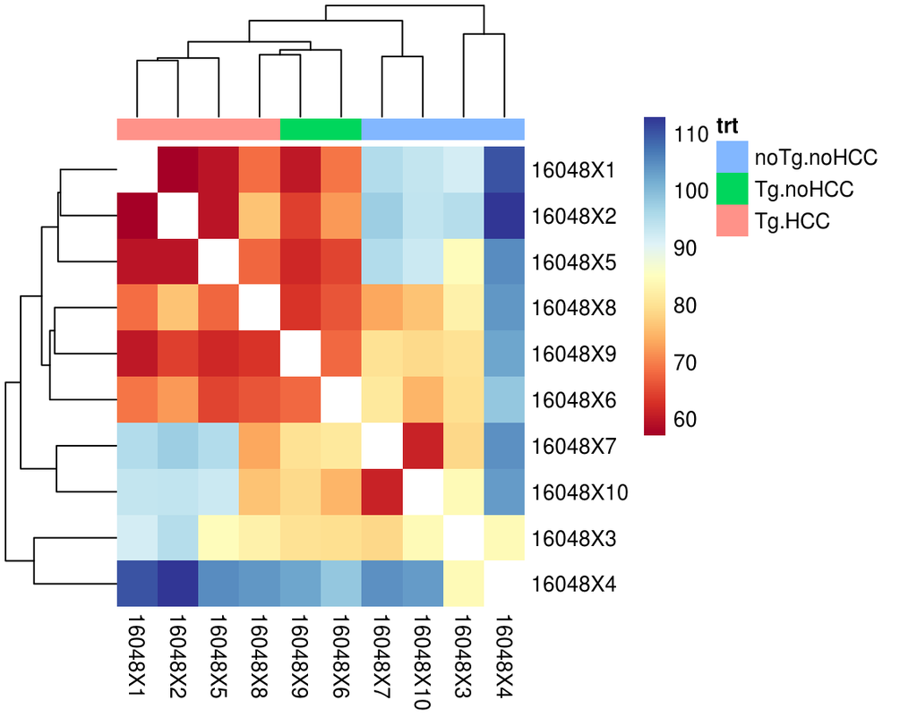

```r
plot_dist(rld, "trt", na="white", annotation_names_col=FALSE)
```

## Tg.HCC vs. Tg.noHCC

Subset the levels Tg.HCC and Tg.noHCC. Re-filter low-expressing genes.

```r
groups1 <- c("Tg.HCC", "Tg.noHCC")
samples1 <- dplyr::filter(samples, trt %in% groups1) %>%
  dplyr::mutate(trt = droplevels(trt)) %>%
  dplyr::mutate(trt = factor(trt, levels = groups1))
stopifnot(identical(samples$id, colnames(counts)[2:11]))
counts1 <- counts[,c("geneid",samples1$id)]
counts1 <- filter_counts(counts1, n = 5)
#  Removed 182 features with 0 reads
#  Removed 1019 features with <=5 maximum reads
```

Re-fit the DESeq2 model.

```r
dds1 <- deseq_from_tibble(counts1, samples1, design = ~ trt )
#  estimating size factors
#  estimating dispersions
#  gene-wise dispersion estimates
#  mean-dispersion relationship
#  final dispersion estimates
#  fitting model and testing
rld1 <- r_log(dds1)
```

Re-do PCA.

```r
plot_pca(rld1, "trt", width=700)
```

[interactive chart not shown]

Cluster samples.

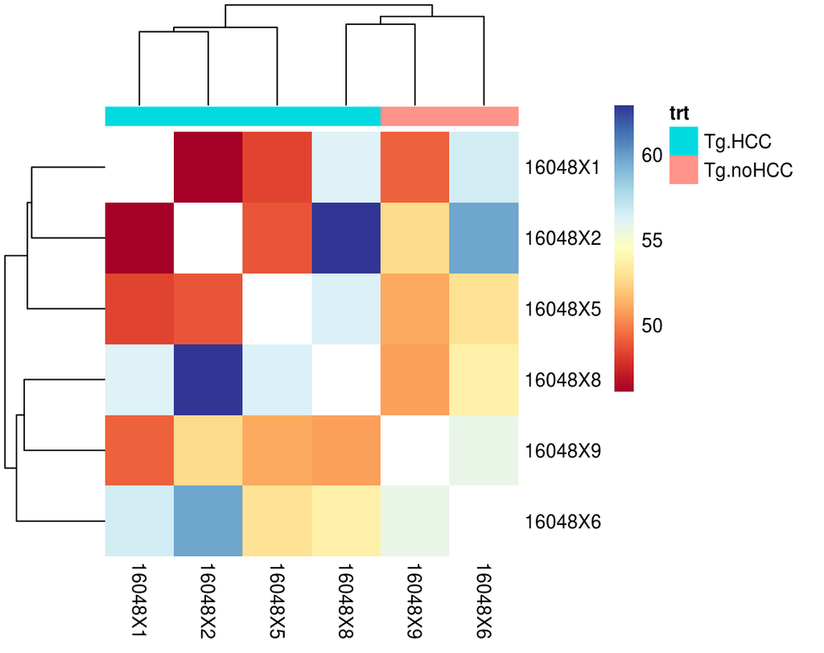

```r
plot_dist(rld1, "trt", na="white", annotation_names_col=FALSE)
```

Infer the differences between pairwise comparison Tg.HCC vs. Tg.noHCC at FDR 5%.

```r
res1 <- results_all(dds1, zebrafish94)
#  Using adjusted p-value < 0.05
#  Adding shrunken fold changes to log2FoldChange
#  1. Tg.HCC vs. Tg.noHCC: 19 up and 34 down regulated
```

Plot fold changes and p-values in a volcano plot.

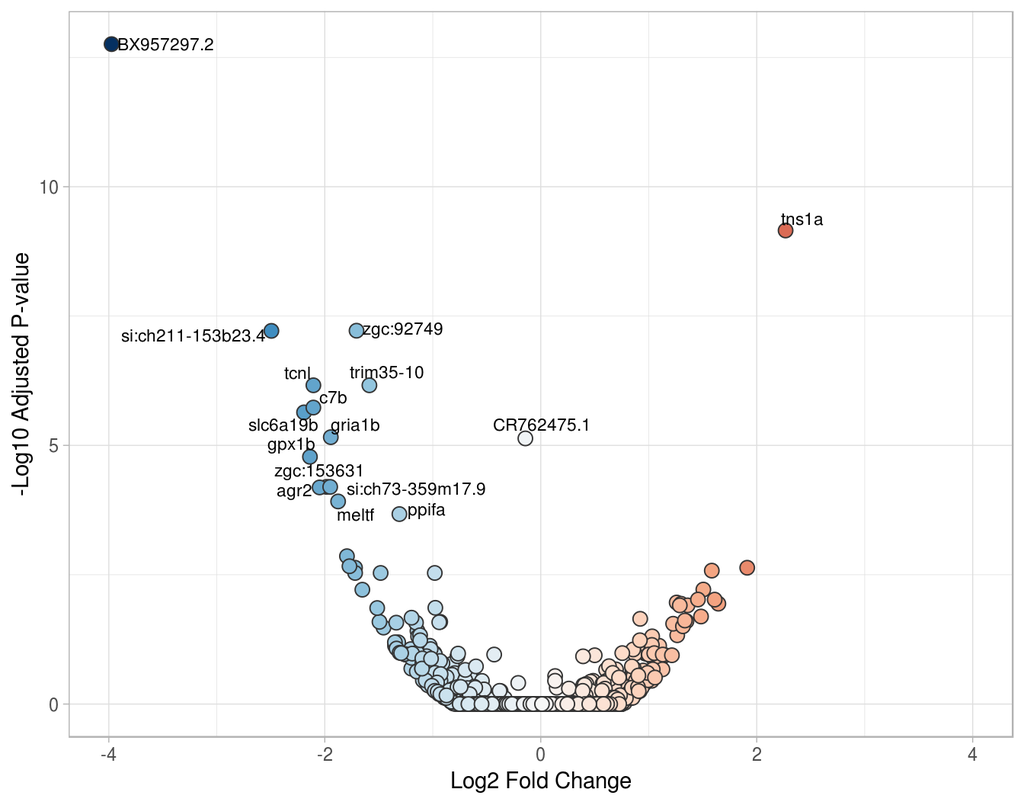

```r
plot_volcano(res1, ggplot=TRUE, pvalue = 3)
```

Cluster the top 50 significant genes sorted by p-value and scale by rows, so values are the number of standard deviations from the mean rlog.

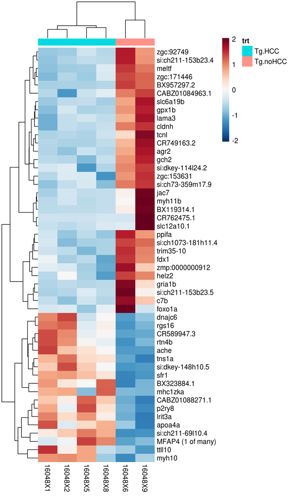

```r
x1 <- top_counts( res1, rld1, top=50)
plot_genes(x1, "trt", scale="row", show_rownames=TRUE, annotation_names_col=FALSE)
```

Save the DESeq results to a single Excel file and R objects to a binary data file to load into a new session. The Excel file will contain raw counts, rlog values, normalized counts, samples and gene annotations in the Excel file.

```r
write_deseq(res1, dds1, rld1, zebrafish94, file = 'Tables/TgHCC_vs_TgnoHCC.xlsx')
#  Tg.HCC vs. Tg.noHCC
#  Saving 7 worksheets to Tables/TgHCC_vs_TgnoHCC.xlsx
#  Note: zip::zip() is deprecated, please use zip::zipr() instead
save(res1, dds1, rld1, zebrafish94, file="Cache/TgHCC_vs_TgnoHCC.rda")
```

## Tg.HCC vs. noTg.noHCC

Subset the levels Tg.HCC and noTg.noHCC. Re-filter low-expressing genes.

```r
groups2 <- c("Tg.HCC", "noTg.noHCC")
samples2 <- dplyr::filter(samples, trt %in% groups2) %>%
  dplyr::mutate(trt = droplevels(trt)) %>%
  dplyr::mutate(trt = factor(trt, levels = groups2))
counts2 <- counts[,c("geneid",samples2$id)]
counts2 <- filter_counts(counts2, n = 5)
#  Removed 2 features with 0 reads
#  Removed 138 features with <=5 maximum reads
```

Re-fit the DESeq2 model.

```r
dds2 <- deseq_from_tibble(counts2, samples2, design = ~ trt )
#  estimating size factors
#  estimating dispersions
#  gene-wise dispersion estimates
#  mean-dispersion relationship
#  final dispersion estimates
#  fitting model and testing
rld2 <- r_log(dds2)
```

Re-do PCA.

```r
plot_pca(rld2, "trt", width=700)
```

[interactive chart not shown]

Cluster samples.

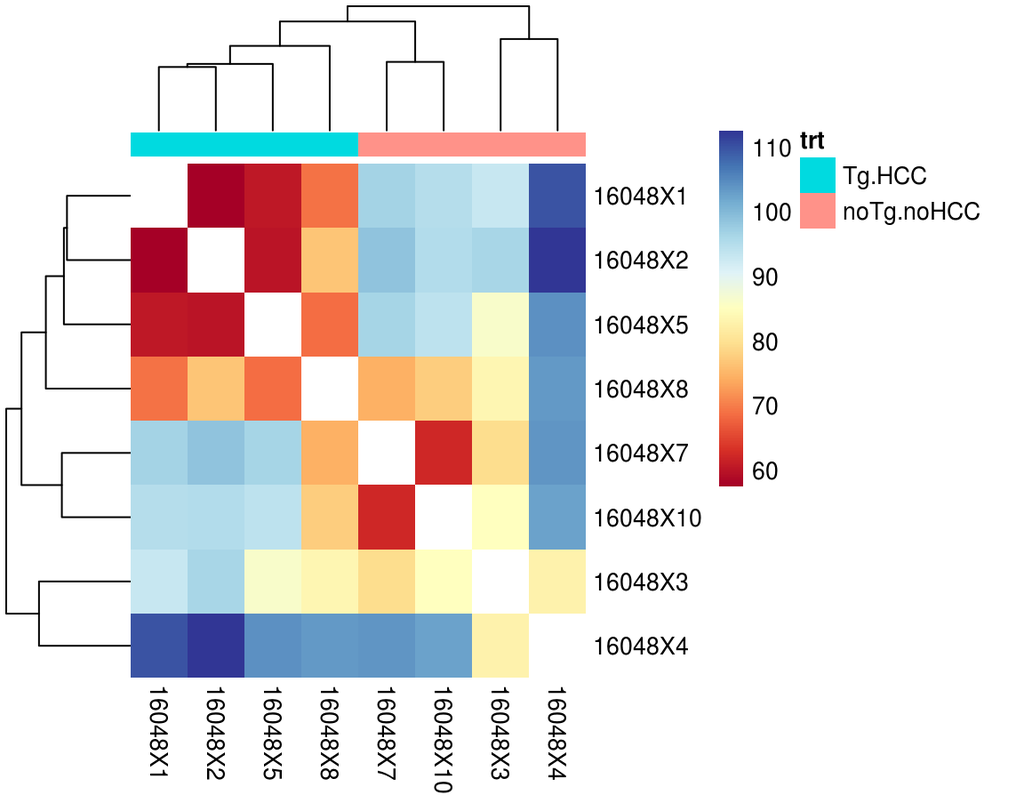

```r
plot_dist(rld2, "trt", na="white", annotation_names_col=FALSE)
```

Infer the differences between pairwise comparison Tg.HCC vs. noTg.noHCC at FDR 5%.

```r
res2 <- results_all(dds2, zebrafish94)
#  Using adjusted p-value < 0.05
#  Adding shrunken fold changes to log2FoldChange
#  1. Tg.HCC vs. noTg.noHCC: 996 up and 1001 down regulated
```

Plot fold changes and p-values in a volcano plot.

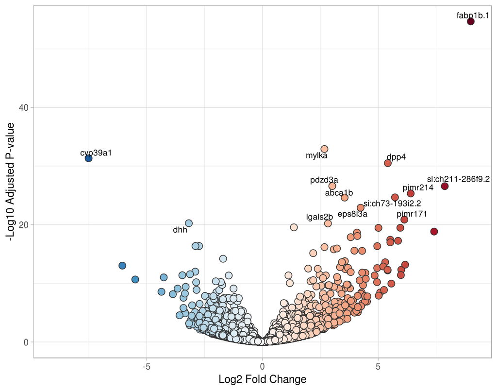

```r
plot_volcano(res2, ggplot=TRUE, pvalue = 20)
```

Cluster the top 50 significant genes sorted by p-value and scale by rows, so values are the number of standard deviations from the mean rlog.

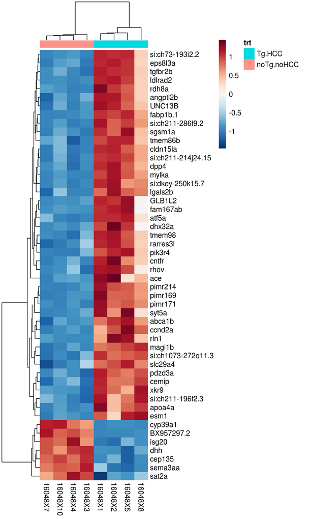

```r
x2 <- top_counts( res2, rld2, top=50)
plot_genes(x2, "trt", scale="row", show_rownames=TRUE, annotation_names_col=FALSE)
```

Save the results.

```r
write_deseq(res2, dds2, rld2, zebrafish94, file = 'Tables/TgHCC_vs_noTgnoHCC.xlsx')
#  Tg.HCC vs. noTg.noHCC
#  Saving 7 worksheets to Tables/TgHCC_vs_noTgnoHCC.xlsx
save(res2, dds2, rld2, zebrafish94, file="Cache/TgHCC_vs_noTgnoHCC.rda")
```

## Tg.noHCC vs. noTg.noHCC

Subset the levels Tg.noHCC and noTg.noHCC. Re-filter low-expressing genes.

```r
groups3 <- c("Tg.noHCC", "noTg.noHCC")
samples3 <- dplyr::filter(samples, trt %in% groups3) %>%
  dplyr::mutate(trt = droplevels(trt)) %>%
  dplyr::mutate(trt = factor(trt, levels = groups3))
counts3 <- counts[,c("geneid",samples3$id)]
counts3 <- filter_counts(counts3, n = 5)
#  Removed 21 features with 0 reads
#  Removed 644 features with <=5 maximum reads
```

Re-fit the DESeq2 model.

```r
dds3 <- deseq_from_tibble(counts3, samples3, design = ~ trt )
#  estimating size factors
#  estimating dispersions
#  gene-wise dispersion estimates
#  mean-dispersion relationship
#  final dispersion estimates
#  fitting model and testing
rld3 <- r_log(dds3)
```

Re-do PCA.

```r
plot_pca(rld3, "trt", width=700)
```

[interactive chart not shown]

Cluster samples.

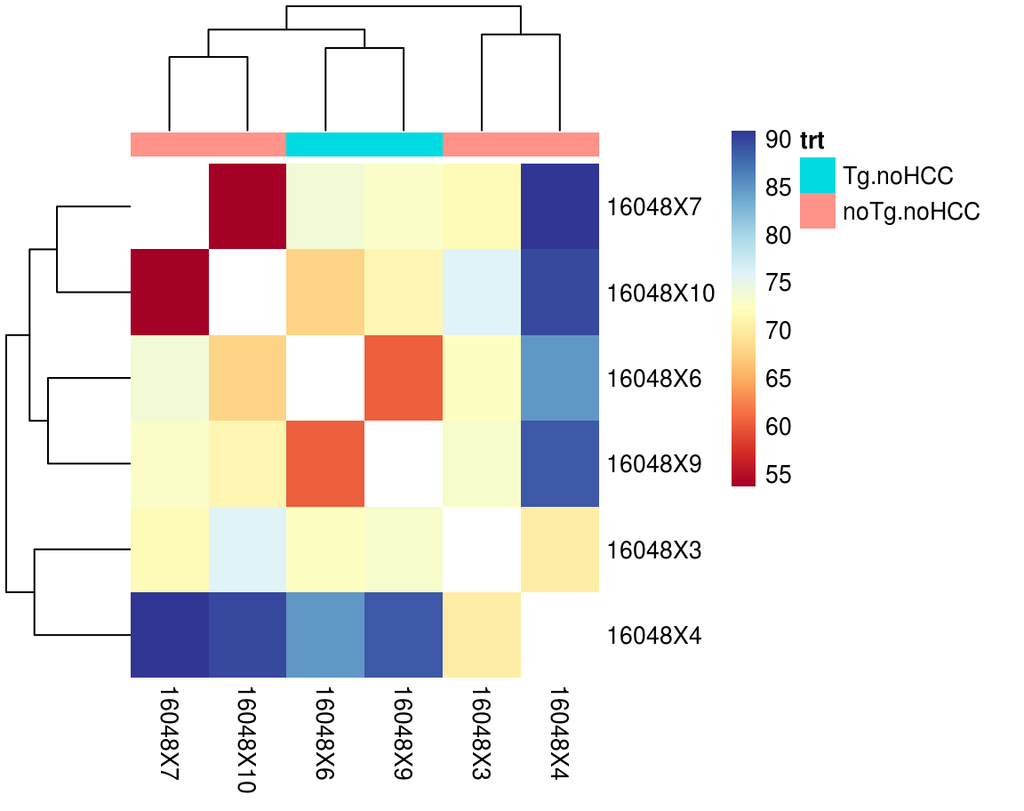

```r
plot_dist(rld3, "trt", na="white", annotation_names_col=FALSE)
```

Infer the differences between pairwise comparison Tg.noHCC vs. noTg.noHCC at FDR 5%.

```r
res3 <- results_all(dds3, zebrafish94)
#  Using adjusted p-value < 0.05
#  Adding shrunken fold changes to log2FoldChange
#  1. Tg.noHCC vs. noTg.noHCC: 167 up and 123 down regulated
```

Plot fold changes and p-values in a volcano plot.

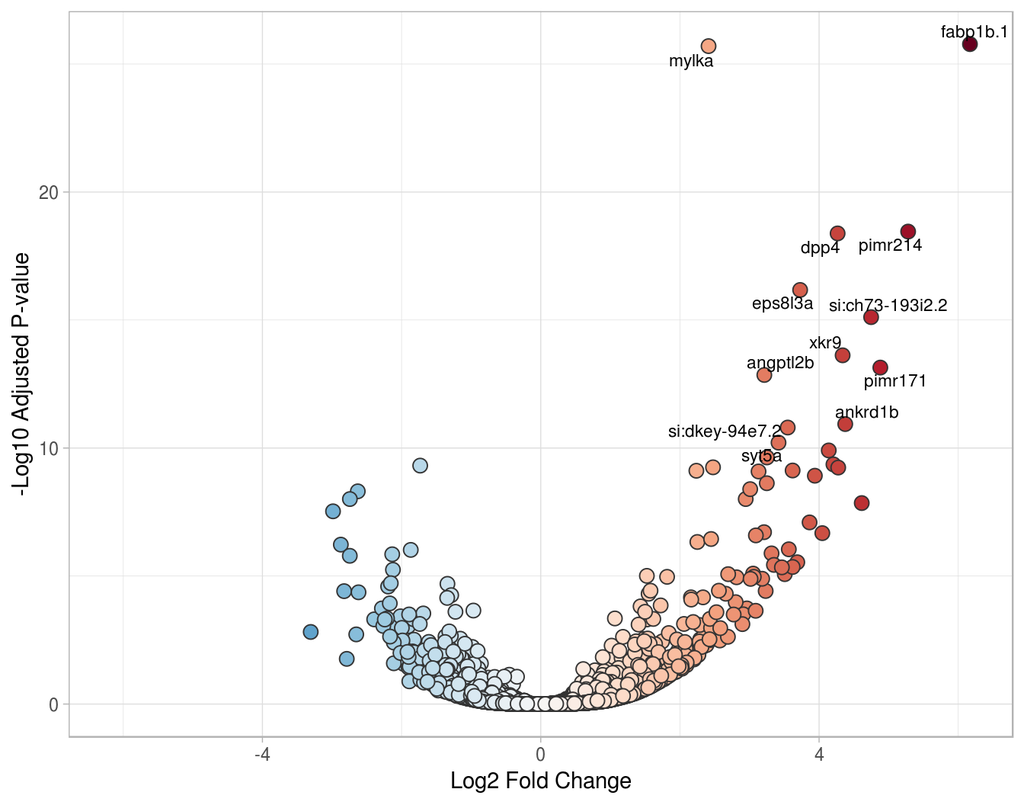

```r
plot_volcano(res3, ggplot=TRUE, pvalue = 10)
```

Cluster the 50 top significant genes sorted by p-value and scale by rows, so values are the number of standard deviations from the mean rlog.

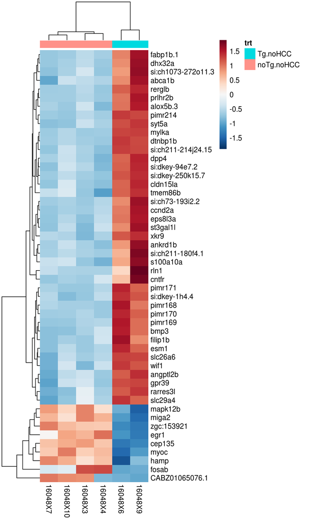

```r
x3 <- top_counts( res3, rld3, top=50)
plot_genes(x3, "trt", scale="row", show_rownames=TRUE, annotation_names_col=FALSE)
```

Save the results.

```r
write_deseq(res3, dds3, rld3, zebrafish94, file = 'Tables/TgnoHCC_vs_noTgnoHCC.xlsx')
#  Tg.noHCC vs. noTg.noHCC
#  Saving 7 worksheets to Tables/TgnoHCC_vs_noTgnoHCC.xlsx
save(res3, dds3, rld3, zebrafish94, file="Cache/TgnoHCC_vs_noTgnoHCC.rda")
```

```r
sessionInfo()
#  R version 3.5.1 (2018-07-02)
#  Platform: x86_64-pc-linux-gnu (64-bit)
#  Running under: CentOS Linux 7 (Core)
#
#  Matrix products: default
#  BLAS: /usr/local/R/3.5.1/lib64/R/lib/libRblas.so
#  LAPACK: /usr/local/R/3.5.1/lib64/R/lib/libRlapack.so
#
#  locale:
#   [1] LC_CTYPE=en_US.UTF-8       LC_NUMERIC=C               LC_TIME=en_US.UTF-8
#   [4] LC_COLLATE=en_US.UTF-8     LC_MONETARY=en_US.UTF-8    LC_MESSAGES=en_US.UTF-8
#   [7] LC_PAPER=en_US.UTF-8       LC_NAME=C                  LC_ADDRESS=C
#  [10] LC_TELEPHONE=C             LC_MEASUREMENT=en_US.UTF-8 LC_IDENTIFICATION=C
#
#  attached base packages:
#  [1] stats     graphics  grDevices utils     datasets  methods   base
#
#  other attached packages:
#  [1] hciRdata_1.96 readr_1.3.1   hciR_1.2.8    dplyr_0.8.0.1
#
#  loaded via a namespace (and not attached):
#    [1] nlme_3.1-139                bitops_1.0-6                matrixStats_0.54.0
#    [4] xts_0.11-2                  lubridate_1.7.4             bit64_0.9-7
#    [7] RColorBrewer_1.1-2          GenomeInfoDb_1.18.2         tools_3.5.1
#   [10] backports_1.1.4             utf8_1.1.4                  R6_2.4.0
#   [13] rpart_4.1-15                Hmisc_4.2-0                 DBI_1.0.0
#   [16] lazyeval_0.2.2              BiocGenerics_0.28.0         colorspace_1.4-1
#   [19] nnet_7.3-12                 tidyselect_0.2.5            gridExtra_2.3
#   [22] DESeq2_1.22.2               curl_3.3                    bit_1.1-14
#   [25] compiler_3.5.1              cli_1.1.0                   Biobase_2.42.0
#   [28] htmlTable_1.13.1            DelayedArray_0.8.0          labeling_0.3
#   [31] scales_1.0.0                checkmate_1.9.1             genefilter_1.64.0
#   [34] stringr_1.3.1               digest_0.6.18               foreign_0.8-71
#   [37] rmarkdown_1.12              XVector_0.22.0              base64enc_0.1-3
#   [40] pkgconfig_2.0.2             htmltools_0.3.6             highcharter_0.7.0
#   [43] TTR_0.23-4                  htmlwidgets_1.3             rlang_0.3.4
#   [46] quantmod_0.4-14             rstudioapi_0.10             RSQLite_2.1.1
#   [49] generics_0.0.2              zoo_1.8-5                   jsonlite_1.6
#   [52] BiocParallel_1.16.6         zip_2.0.1                   acepack_1.4.1
#   [55] rlist_0.4.6.1               RCurl_1.95-4.12             magrittr_1.5
#   [58] GenomeInfoDbData_1.2.0      Formula_1.2-3               Matrix_1.2-17
#   [61] Rcpp_1.0.0                  munsell_0.5.0               S4Vectors_0.20.1
#   [64] fansi_0.4.0                 whisker_0.3-2               stringi_1.2.4
#   [67] yaml_2.2.0                  SummarizedExperiment_1.12.0 zlibbioc_1.28.0
#   [70] plyr_1.8.4                  grid_3.5.1                  blob_1.1.1
#   [73] ggrepel_0.8.0               parallel_3.5.1              crayon_1.3.4
#   [76] lattice_0.20-38             splines_3.5.1               annotate_1.60.1
#   [79] hms_0.4.2                   locfit_1.5-9.1              knitr_1.22
#   [82] pillar_1.3.1                igraph_1.2.4                GenomicRanges_1.34.0
#   [85] geneplotter_1.60.0          stats4_3.5.1                XML_3.98-1.19
#   [88] glue_1.3.0                  evaluate_0.13               latticeExtra_0.6-28
#   [91] data.table_1.11.4           tidyr_0.8.3                 gtable_0.3.0
#   [94] purrr_0.3.2                 assertthat_0.2.1            ggplot2_3.0.0
#   [97] openxlsx_4.1.0              dendsort_0.3.3              xfun_0.6
#  [100] xtable_1.8-3                broom_0.5.2                 survival_2.44-1.1
#  [103] pheatmap_1.0.12             tibble_2.1.1                AnnotationDbi_1.44.0
#  [106] memoise_1.1.0               IRanges_2.16.0              cluster_2.0.8
```